# Binary Classification with a Bank Churn Dataset

Humphrey Afobhokhan

2024-02-05

# Introduction

This project delves into binary classification within the banking sector, focusing on customer churn prediction based on Kaggle’s Bank Churn Dataset. It aims to discern patterns that influence customers’ decisions to stay with or leave their bank. Utilizing statistical analysis and machine learning in R, this study addresses data preprocessing, explores key factors affecting churn, and applies predictive modeling to forecast customer behavior. Through this analysis, we seek to uncover insights that could help banks enhance customer retention strategies.

```r
#import and read file
getwd()
```

```
## [1] "/Users/badboihy/Downloads/Visualizing & Analyzing Data with R - Methods & Tools"
```

```r
setwd("/Users/badboihy/Downloads/Visualizing & Analyzing Data with R - Methods & Tools")
getwd()
```

```
## [1] "/Users/badboihy/Downloads/Visualizing & Analyzing Data with R - Methods & Tools"
```

```r
df.train <- read.csv('BankChurnDataset-2.csv')
head(df.train)
```

|  | id | CustomerId | Surname | CreditScore | Geography | Gender | Age | Tenure | Balance | NumOfProducts | HasCrCard | IsActiveMember | EstimatedSalary | Exited |
| --- | --- | --- | --- | --- | --- | --- | --- | --- | --- | --- | --- | --- | --- | --- |
| 1 | 0 | 15674932 | Okwudilichukwu | 668 | France | Male | 33 | 3 | 0.0 | 2 | 1 | 0 | 181449.97 | 0 |
| 2 | 1 | 15749177 | Okwudiliolisa | 627 | France | Male | 33 | 1 | 0.0 | 2 | 1 | 1 | 49503.50 | 0 |
| 3 | 2 | 15694510 | Hsueh | 678 | France | Male | NA | 10 | 0.0 | 2 | 1 | 0 | 184866.69 | 0 |
| 4 | 3 | 15741417 | Kao | 581 | France | Male | 34 | 2 | 148882.5 | 1 | 1 | 1 | NA | 0 |
| 5 | 4 | 15766172 | Chiemenam | 716 | Spain | Male | 33 | 5 | 0.0 | 2 | 1 | 1 | 15068.83 | 0 |
| 6 | 5 | 15771669 | Genovese | 588 | Germany | Male | 36 | 4 | 131778.6 | 1 | 1 | 0 | 136024.31 | 1 |

```r
str(df.train)
```

```
## 'data.frame':    165034 obs. of  14 variables:
##  $ id             : int  0 1 2 3 4 5 6 7 8 9 ...
##  $ CustomerId     : int  15674932 15749177 15694510 15741417 15766172 15771669 15692819 15669611 15691707 15591721 ...
##  $ Surname        : chr  "Okwudilichukwu" "Okwudiliolisa" "Hsueh" "Kao" ...
##  $ CreditScore    : int  668 627 678 581 716 588 593 678 676 583 ...
##  $ Geography      : chr  "France" "France" "France" "France" ...
##  $ Gender         : chr  "Male" "Male" "Male" "Male" ...
##  $ Age            : num  33 33 NA 34 33 36 30 37 43 40 ...
##  $ Tenure         : int  3 1 10 2 5 4 8 1 4 4 ...
##  $ Balance        : num  0 0 0 148883 0 ...
##  $ NumOfProducts  : int  2 2 2 1 2 1 1 1 2 1 ...
##  $ HasCrCard      : int  1 1 1 1 1 1 1 1 1 1 ...
##  $ IsActiveMember : int  0 1 0 1 1 0 0 0 0 1 ...
##  $ EstimatedSalary: num  181450 49504 184867 NA 15069 ...
##  $ Exited         : int  0 0 0 0 0 1 0 0 0 0 ...
```

```r
summary(df.train)
```

```
##        id           CustomerId         Surname           CreditScore
##  Min.   :     0   Min.   :15565701   Length:165034      Min.   :350.0
##  1st Qu.: 41258   1st Qu.:15633141   Class :character   1st Qu.:597.0
##  Median : 82516   Median :15690169   Mode  :character   Median :659.0
##  Mean   : 82516   Mean   :15692005                      Mean   :656.5
##  3rd Qu.:123775   3rd Qu.:15756824                      3rd Qu.:710.0
##  Max.   :165033   Max.   :15815690                      Max.   :850.0
##
##   Geography            Gender               Age            Tenure
##  Length:165034      Length:165034      Min.   :18.00   Min.   : 0.00
##  Class :character   Class :character   1st Qu.:32.00   1st Qu.: 3.00
##  Mode  :character   Mode  :character   Median :37.00   Median : 5.00
##                                        Mean   :38.13   Mean   : 5.02
##                                        3rd Qu.:42.00   3rd Qu.: 7.00
##                                        Max.   :92.00   Max.   :10.00
##                                        NA's   :6
##     Balance       NumOfProducts     HasCrCard     IsActiveMember
##  Min.   :     0   Min.   :1.000   Min.   :0.000   Min.   :0.0000
##  1st Qu.:     0   1st Qu.:1.000   1st Qu.:1.000   1st Qu.:0.0000
##  Median :     0   Median :2.000   Median :1.000   Median :0.0000
##  Mean   : 55478   Mean   :1.554   Mean   :0.754   Mean   :0.4978
##  3rd Qu.:119940   3rd Qu.:2.000   3rd Qu.:1.000   3rd Qu.:1.0000
##  Max.   :250898   Max.   :4.000   Max.   :1.000   Max.   :1.0000
##
##  EstimatedSalary         Exited
##  Min.   :    11.58   Min.   :0.0000
##  1st Qu.: 74637.57   1st Qu.:0.0000
##  Median :117948.00   Median :0.0000
##  Mean   :112575.32   Mean   :0.2116
##  3rd Qu.:155155.25   3rd Qu.:0.0000
##  Max.   :199992.48   Max.   :1.0000
##  NA's   :3
```

```r
summary(df.train$EstimatedSalary)
```

```
##      Min.   1st Qu.    Median      Mean   3rd Qu.      Max.      NA's
##     11.58  74637.57 117948.00 112575.32 155155.25 199992.48         3
```

```r
# Handling missing Estimated Salary missing Estimated Salary values
df.train$EstimatedSalary[is.na(df.train$EstimatedSalary)] <-
  median(df.train$EstimatedSalary, na.rm = TRUE)

# Checking out Estimated Salary
summary(df.train$EstimatedSalary)
```

```
##      Min.   1st Qu.    Median      Mean   3rd Qu.      Max.
##     11.58  74637.60 117948.00 112575.42 155152.47 199992.48
```

```r
# Age Imputation, handling missing values in age

  impute_age <- function(age,class){
    out <- age
    for (i in 1:length(age)){

      if (is.na(age[i])){

        if (class[i] == 1){
          out[i] <- 42

        }else if (class[i] == 2){
          out[i] <- 37

        }else{
          out[i] <- 32
        }
      }else{
        out[i]<-age[i]
      }
    }
    return(out)
  }

fixed.ages <- impute_age(df.train$Age, df.train$HasCrCard)
df.train$Age <- fixed.ages

summary(df.train$Age)
```

```
##    Min. 1st Qu.  Median    Mean 3rd Qu.    Max.
##   18.00   32.00   37.00   38.13   42.00   92.00
```

```r
#Exploratory data analysis, finding out missing value
library(Amelia)
```

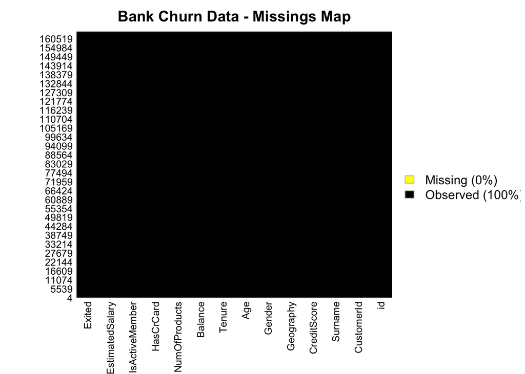

```r
missmap(df.train, main="Bank Churn Data - Missings Map",
        col=c("yellow", "black"), legend=TRUE)
```

```r
# Remove ineffective features
options(repos = c(CRAN = "https://cran.rstudio.com"))

install.packages("dplyr")
library(dplyr)
df.train <- select(df.train, -id, -CustomerId, -Surname)

# checking remaining columns
head(df.train,3)
```

|  | CreditScore | Geography | Gender | Age | Tenure | Balance | NumOfProducts | HasCrCard | IsActiveMember | EstimatedSalary | Exited |
| --- | --- | --- | --- | --- | --- | --- | --- | --- | --- | --- | --- |
| 1 | 668 | France | Male | 33 | 3 | 0 | 2 | 1 | 0 | 181450.0 | 0 |
| 2 | 627 | France | Male | 33 | 1 | 0 | 2 | 1 | 1 | 49503.5 | 0 |
| 3 | 678 | France | Male | 42 | 10 | 0 | 2 | 1 | 0 | 184866.7 | 0 |

```r
str(df.train)
```

```
## 'data.frame':    165034 obs. of  11 variables:
##  $ CreditScore    : int  668 627 678 581 716 588 593 678 676 583 ...
##  $ Geography      : chr  "France" "France" "France" "France" ...
##  $ Gender         : chr  "Male" "Male" "Male" "Male" ...
##  $ Age            : num  33 33 42 34 33 36 30 37 43 40 ...
##  $ Tenure         : int  3 1 10 2 5 4 8 1 4 4 ...
##  $ Balance        : num  0 0 0 148883 0 ...
##  $ NumOfProducts  : int  2 2 2 1 2 1 1 1 2 1 ...
##  $ HasCrCard      : int  1 1 1 1 1 1 1 1 1 1 ...
##  $ IsActiveMember : int  0 1 0 1 1 0 0 0 0 1 ...
##  $ EstimatedSalary: num  181450 49504 184867 117948 15069 ...
##  $ Exited         : int  0 0 0 0 0 1 0 0 0 0 ...
```

```r
# Converting features to factors
df.train$Geography      <- as.factor(df.train$Geography)
df.train$Gender         <- as.factor(df.train$Gender)
df.train$HasCrCard.     <- as.factor(df.train$HasCrCard)
df.train$IsActiveMember <- as.factor(df.train$IsActiveMember)

str(df.train)
```

```
## 'data.frame':    165034 obs. of  12 variables:
##  $ CreditScore    : int  668 627 678 581 716 588 593 678 676 583 ...
##  $ Geography      : Factor w/ 3 levels "France","Germany",..: 1 1 1 1 3 2 1 3 1 2 ...
##  $ Gender         : Factor w/ 2 levels "Female","Male": 2 2 2 2 2 2 1 2 2 2 ...
##  $ Age            : num  33 33 42 34 33 36 30 37 43 40 ...
##  $ Tenure         : int  3 1 10 2 5 4 8 1 4 4 ...
##  $ Balance        : num  0 0 0 148883 0 ...
##  $ NumOfProducts  : int  2 2 2 1 2 1 1 1 2 1 ...
##  $ HasCrCard      : int  1 1 1 1 1 1 1 1 1 1 ...
##  $ IsActiveMember : Factor w/ 2 levels "0","1": 1 2 1 2 2 1 1 1 1 2 ...
##  $ EstimatedSalary: num  181450 49504 184867 117948 15069 ...
##  $ Exited         : int  0 0 0 0 0 1 0 0 0 0 ...
##  $ HasCrCard.     : Factor w/ 2 levels "0","1": 2 2 2 2 2 2 2 2 2 2 ...
```

```r
df.train <- select(df.train, -HasCrCard.)

str(df.train)
```

```
## 'data.frame':    165034 obs. of  11 variables:
##  $ CreditScore    : int  668 627 678 581 716 588 593 678 676 583 ...
##  $ Geography      : Factor w/ 3 levels "France","Germany",..: 1 1 1 1 3 2 1 3 1 2 ...
##  $ Gender         : Factor w/ 2 levels "Female","Male": 2 2 2 2 2 2 1 2 2 2 ...
##  $ Age            : num  33 33 42 34 33 36 30 37 43 40 ...
##  $ Tenure         : int  3 1 10 2 5 4 8 1 4 4 ...
##  $ Balance        : num  0 0 0 148883 0 ...
##  $ NumOfProducts  : int  2 2 2 1 2 1 1 1 2 1 ...
##  $ HasCrCard      : int  1 1 1 1 1 1 1 1 1 1 ...
##  $ IsActiveMember : Factor w/ 2 levels "0","1": 1 2 1 2 2 1 1 1 1 2 ...
##  $ EstimatedSalary: num  181450 49504 184867 117948 15069 ...
##  $ Exited         : int  0 0 0 0 0 1 0 0 0 0 ...
```

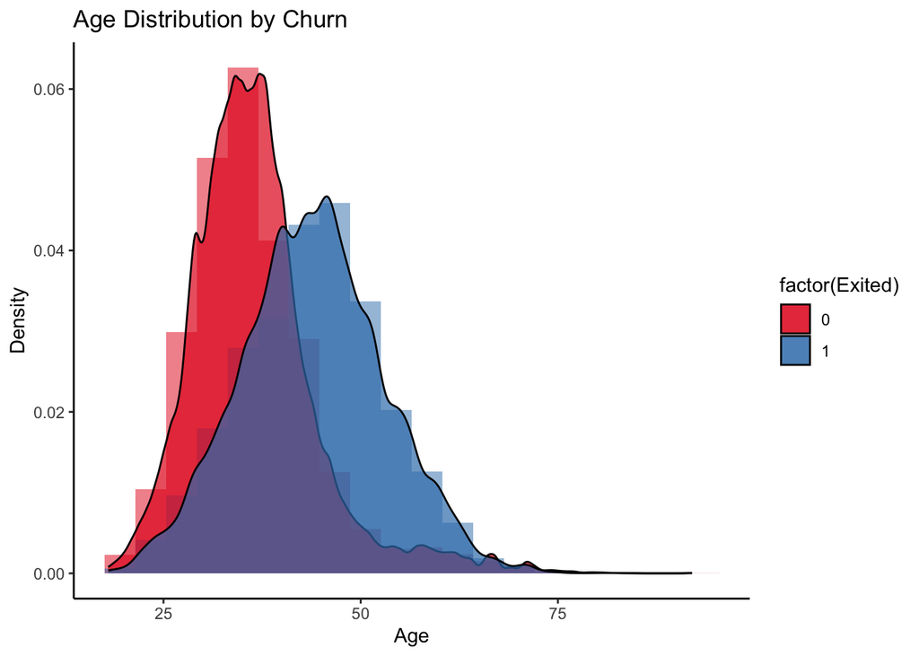

```r
# Exploratory data analysis using GGPlot

library(ggplot2)

# For Age and Churn
ggplot(df.train, aes(x = Age, fill = factor(Exited))) +
  geom_histogram(aes(y = ..density..), position = "identity",
                 bins = 20, alpha = 0.5) +
  geom_density(alpha = 0.7) +
  scale_fill_brewer(palette = "Set1") +
  labs(title = "Age Distribution by Churn", x = "Age", y = "Density") +
  theme_classic()
```

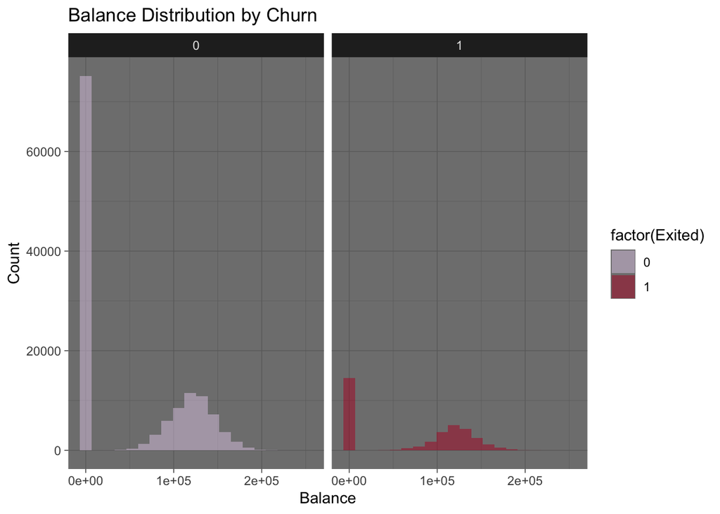

```r
# For Balance and Churn
ggplot(df.train, aes(x = Balance, fill = factor(Exited))) +
  geom_histogram(position = "identity", bins = 20, alpha = 0.5) +
  facet_grid(. ~ Exited) +
  scale_fill_manual(values = c("0" = "#DECBE4", "1" = "#B2182B")) +
  labs(title = "Balance Distribution by Churn", x = "Balance", y = "Count") +
  theme_dark()
```

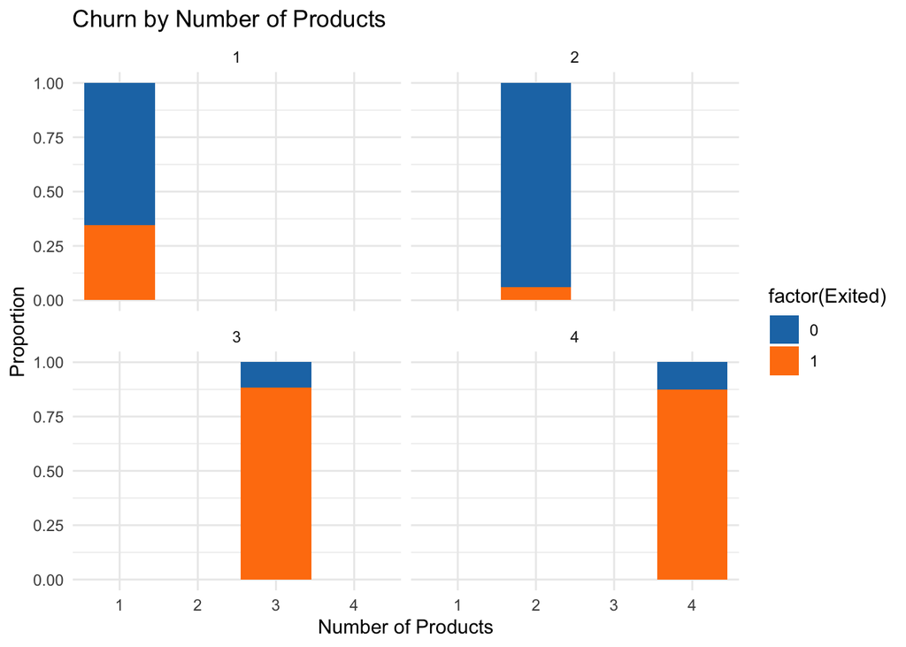

```r
# For NumOfProducts and Churn
ggplot(df.train, aes(x = factor(NumOfProducts), fill = factor(Exited))) +
  geom_bar(position = "fill") +
  facet_wrap(~NumOfProducts) +
  scale_fill_manual(values = c("0" = "#1f77b4", "1" = "#ff7f0e")) +
  labs(title = "Churn by Number of Products",
       x = "Number of Products", y = "Proportion") +
  theme_minimal()
```

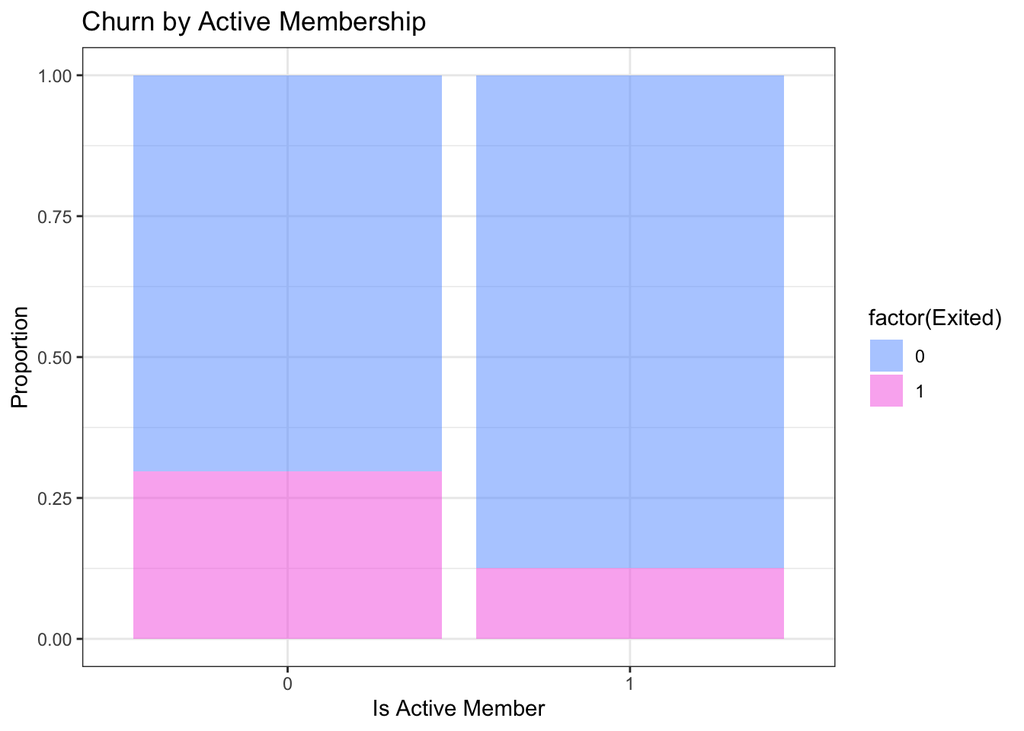

```r
# For IsActiveMember and Churn
ggplot(df.train, aes(x = factor(IsActiveMember), fill = factor(Exited))) +
  geom_bar(position = "fill", alpha = 0.5) +
  scale_fill_manual(values = c("0" = "#619CFF", "1" = "#F564E3")) +
  labs(title = "Churn by Active Membership",
       x = "Is Active Member", y = "Proportion") +
  theme_bw()
```

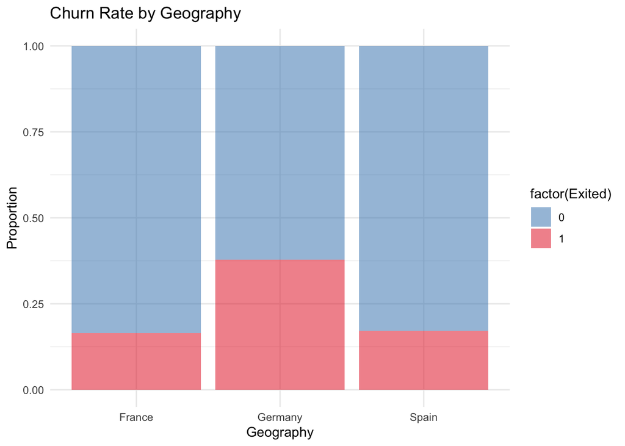

```r
# For Geography and Churn
ggplot(df.train, aes(x = Geography, fill = factor(Exited))) +
  geom_bar(position = "fill", alpha = 0.5) +
  scale_fill_brewer(palette = "Set1", direction = -1) +
  labs(title = "Churn Rate by Geography",
       x = "Geography", y = "Proportion") +
  theme_minimal()
```

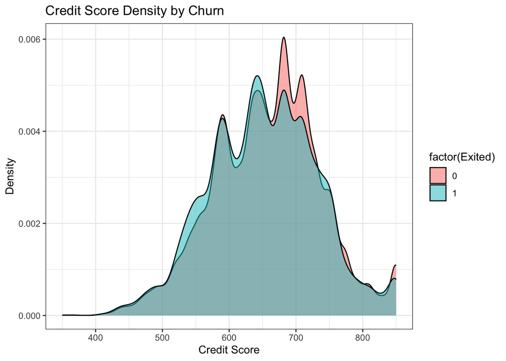

```r
# For CreditScore and Churn
ggplot(df.train, aes(x = CreditScore, fill = factor(Exited))) +
  geom_density(alpha = 0.5) +
  scale_fill_manual(values = c("0" = "#F8766D", "1" = "#00BFC4")) +
  labs(title = "Credit Score Density by Churn",
       x = "Credit Score", y = "Density") +
  theme_bw()
```

```r
# 'Exited' is the target variable

# Load the necessary package for sampling
install.packages("caTools")
library(caTools)

# Set a seed for reproducibility
set.seed(101)

# Split the data into training and testing sets
split = sample.split(df.train$Exited, SplitRatio = 0.70)
final.train = subset(df.train, split == TRUE)
final.test = subset(df.train, split == FALSE)
```

```r
# Train the logistic regression model
final.log.model <- glm(Exited ~ ., family = binomial(link = 'logit'),
                       data = df.train)

# Summarize the model
summary(final.log.model)
```

```
##
## Call:
## glm(formula = Exited ~ ., family = binomial(link = "logit"),
##     data = df.train)
##
## Coefficients:
##                    Estimate Std. Error z value Pr(>|z|)
## (Intercept)      -2.431e+00  7.330e-02 -33.172  < 2e-16 ***
## CreditScore      -7.957e-04  8.679e-05  -9.168  < 2e-16 ***
## GeographyGermany  1.149e+00  1.971e-02  58.287  < 2e-16 ***
## GeographySpain    3.167e-02  1.842e-02   1.720   0.0855 .
## GenderMale       -6.669e-01  1.399e-02 -47.666  < 2e-16 ***
## Age               9.411e-02  7.886e-04 119.345  < 2e-16 ***
## Tenure           -1.543e-02  2.480e-03  -6.220 4.97e-10 ***
## Balance          -1.986e-06  1.422e-07 -13.968  < 2e-16 ***
## NumOfProducts    -9.130e-01  1.378e-02 -66.263  < 2e-16 ***
## HasCrCard        -1.610e-01  1.596e-02 -10.084  < 2e-16 ***
## IsActiveMember1  -1.282e+00  1.500e-02 -85.479  < 2e-16 ***
## EstimatedSalary   9.414e-07  1.391e-07   6.767 1.31e-11 ***
## ---
## Signif. codes:  0 '***' 0.001 '**' 0.01 '*' 0.05 '.' 0.1 ' ' 1
##
## (Dispersion parameter for binomial family taken to be 1)
##
##     Null deviance: 170337  on 165033  degrees of freedom
## Residual deviance: 130536  on 165022  degrees of freedom
## AIC: 130560
##
## Number of Fisher Scoring iterations: 5
```

```r
# Predict on the test set
fitted.probabilities <- predict(final.log.model,
                                newdata = final.test, type = 'response')
fitted.results <- ifelse(fitted.probabilities > 0.5, 1, 0)

# Calculate and print the accuracy
misClasificError <- mean(fitted.results != final.test$Exited)
print(paste('Accuracy:', 1 - misClasificError))
```

```
## [1] "Accuracy: 0.83474045647344"
```